# Titanic data exploration using GLM, KNN, SVN, xgboost, random forests

We saw that there is no use in columns Surname,Cabin,Name,CabinNumber,Title,CabinLetter for glm model that we want to interpret. Let’s create glm ignoring these columns and using whole training data and try to check what predictors are the most reliable.

```r
cTrain = subset(train,select=-c(Cabin,Name,Ticket,PassengerId))
#impute Age - this will give us extra 0.01 in prediction accuaracy
cTrain$Age[is.na(cTrain$Age)] <- mean(cTrain$Age,na.rm=T)
cTrain = na.omit(cTrain)
dim(cTrain)
```

```
## [1] 889   8
```

```r
cTrain$Survived = factor(cTrain$Survived)
cTrain$Pclass = factor(cTrain$Pclass)
glmfit = glm(Survived~.,data=cTrain,family=binomial);
summary(glmfit)
```

```
##
## Call:
## glm(formula = Survived ~ ., family = binomial, data = cTrain)
##
## Deviance Residuals:
##     Min       1Q   Median       3Q      Max
## -2.6235  -0.6098  -0.4237   0.6112   2.4512
##
## Coefficients:
##              Estimate Std. Error z value Pr(>|z|)
## (Intercept)  4.102784   0.476303   8.614  < 2e-16 ***
## Pclass2     -0.924047   0.297882  -3.102  0.00192 **
## Pclass3     -2.149626   0.297749  -7.220 5.21e-13 ***
## Sexmale     -2.709611   0.201336 -13.458  < 2e-16 ***
## Age         -0.039320   0.007888  -4.984 6.21e-07 ***
## SibSp       -0.322143   0.109545  -2.941  0.00327 **
## Parch       -0.095061   0.119028  -0.799  0.42450
## Fare         0.002261   0.002462   0.918  0.35842
## EmbarkedQ   -0.029839   0.381534  -0.078  0.93766
## EmbarkedS   -0.445754   0.239730  -1.859  0.06297 .
## ---
## Signif. codes:  0 '***' 0.001 '**' 0.01 '*' 0.05 '.' 0.1 ' ' 1
##
## (Dispersion parameter for binomial family taken to be 1)
##
##     Null deviance: 1182.82  on 888  degrees of freedom
## Residual deviance:  783.74  on 879  degrees of freedom
## AIC: 803.74
##
## Number of Fisher Scoring iterations: 5
```

We see that the reliable predictors are the same as those we saw on partial data glm plus Pclass and SibSp VIFs are also ok for the whole data.

```r
corvif(cTrain)
```

```
##
##
## Variance inflation factors
##
##              GVIF Df GVIF^(1/2Df)
## Survived 1.657345  1     1.287379
## Pclass   2.163392  2     1.212785
## Sex      1.536380  1     1.239508
## Age      1.257292  1     1.121290
## SibSp    1.297529  1     1.139091
## Parch    1.336205  1     1.155943
## Fare     1.764608  1     1.328386
## Embarked 1.240214  2     1.055296
```

It is also useful to make predictors vs response plot and look for visual trends and non-linearities. Again, quoting [A protocol for data exploration to avoid common statistical problems](http://onlinelibrary.wiley.com/doi/10.1111/j.2041-210X.2009.00001.x/full) “Note that the absence of clear patterns does not mean that there are no relationships; it just means that there are no clear two-way relationships. A model with multiple explanatory variables may still provide a good fit.”

```
##         Pclass
## Survived   1   2   3
##        0  80  97 372
##        1 134  87 119
```

```
##         Sex
## Survived female male
##        0     81  468
##        1    231  109
```

[output not shown]

[output not shown]

[output not shown]

[output not shown]

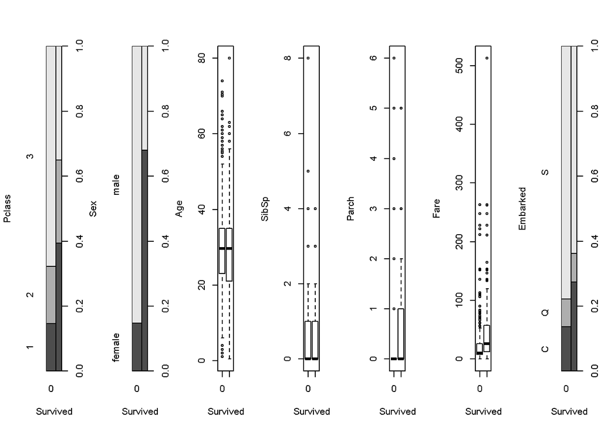

```
##         Embarked
## Survived   C   Q   S
##        0  75  47 427
##        1  93  30 217
```

```r
plotPredictors('Survived',cTrain)
```

Plot glm predictions to interpret every predictor.

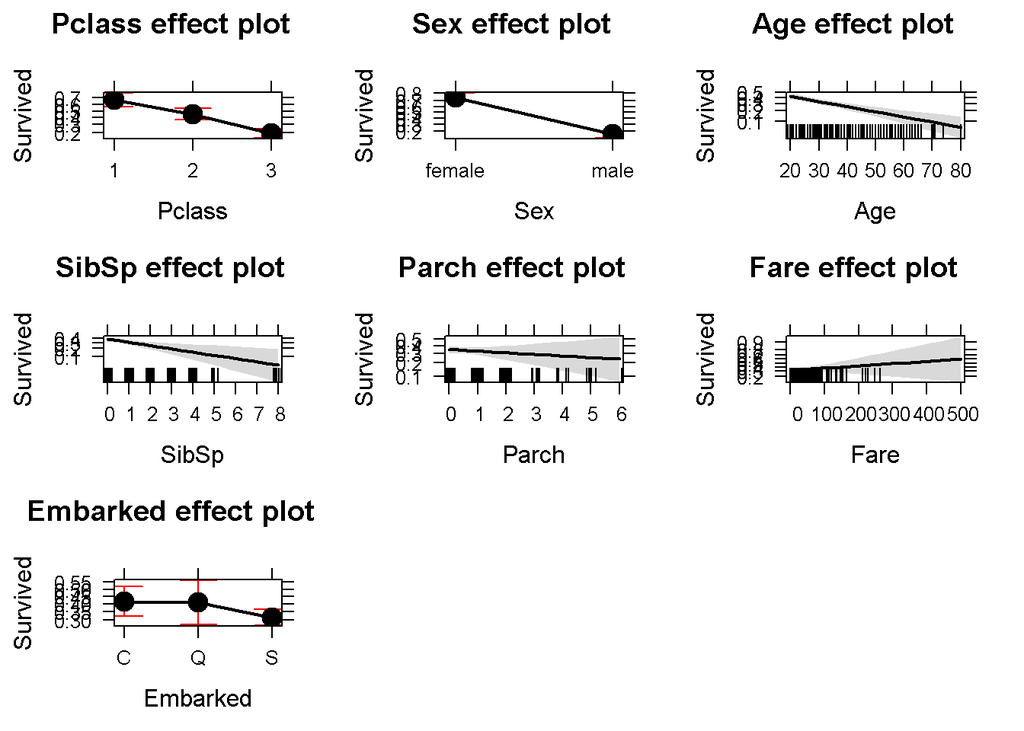

```r
library(effects)
plot(allEffects(glmfit))
```

Finally get confusion matrix for this model

```r
# split cTrain on train and test
set.seed(726)
inTrain <- createDataPartition(cTrain$Survived, p = 0.7, list = FALSE)
cTrainTrain <- cTrain[inTrain, ]
cTrainTest <- cTrain[-inTrain, ]
# check how data is splitted
table(cTrainTrain$Survived)
```

```
##
##   0   1
## 385 238
```

```r
table(cTrainTest$Survived)
```

```
##
##   0   1
## 164 102
```

```r
# make model fit on train data
glmfit = glm(Survived~.,data=cTrainTrain,family=binomial);
# predict test data
pr = factor(ifelse(predict(glmfit, newdata = cTrainTest) > 0.5,1,0))
confusionMatrix(cTrainTest$Survived, pr)
```

```
## Confusion Matrix and Statistics
##
##           Reference
## Prediction   0   1
##          0 152  12
##          1  40  62
##
##                Accuracy : 0.8045
##                  95% CI : (0.7517, 0.8504)
##     No Information Rate : 0.7218
##     P-Value [Acc > NIR] : 0.001203
##
##                   Kappa : 0.5639
##  Mcnemar's Test P-Value : 0.000181
##
##             Sensitivity : 0.7917
##             Specificity : 0.8378
##          Pos Pred Value : 0.9268
##          Neg Pred Value : 0.6078
##              Prevalence : 0.7218
##          Detection Rate : 0.5714
##    Detection Prevalence : 0.6165
##       Balanced Accuracy : 0.8148
##
##        'Positive' Class : 0
##
```

Let’s use more exact method of estimating test error - cross-validation.

```r
# Use 10-fold cross-validation
glmfit = glm(Survived~.,data=cTrain,family=binomial);
error = cv.glm(cTrain, glmfit,K=10)
# standard k-fold CV estimate
error$delta [1]
```

```
## [1] 0.1434622
```

```r
# bias corrected version k-fold CV estimate
error$delta [2]
```

```
## [1] 0.1432422
```

```r
test <- read.csv('test.csv',na.strings=c(""))
cTest = preprocessTitanic(test);
```

```
##   missForest iteration 1 in progress...done!
##   missForest iteration 2 in progress...done!
##   missForest iteration 3 in progress...done!
```

```r
pr = predict(glmfit, newdata = cTest, type='response')
write.csv(data.frame(PassengerId = test$PassengerId, Survived = as.numeric(pr>0.5)), file = "TitanicGLM.csv")
```

We can also consider interaction of predictors.

```r
# Stepwise Regression
library(MASS)
glmfit = glm(Survived~.^2, cTrain, family=binomial);
step <- stepAIC(glmfit, direction="both",trace=FALSE)
#step$anova # display results

# return initial layout
par(mfrow=c(1,1))
error = cv.glm(cTrain, glmfit,K=10)
# standard k-fold CV estimate
error$delta [1]
```

```
## [1] 0.1376354
```

```r
# bias corrected version k-fold CV estimate
error$delta [2]
```

```
## [1] 0.1363836
```

Decrease in CV error is small and we get warnings about possible overfit. In addition I am not sure how to interpret this interactions. So we stop on version without them.

I should note that because logistic regression doesn’t have a specific target function, it is difficult to diagnose the fit. (It is possible to define “residuals” for logistic regression but they are difficult to interpret)[http://alumni.media.mit.edu/~tpminka/courses/36-350.2001/lectures/day31/]. So we will end up with conclusion that the significant predictors are Sex, Age, Pclass, SibSp. With slope and confidence intervals showed above.

## Using GLM for prediction

In this section we will use GLM to make predictions and will not think about interpretability of the model.

First of all, lets impute all NA data.

```r
# create data from scratch
train <- read.csv('train.csv',na.strings=c(""))
test <- read.csv('test.csv',na.strings=c(""))

cTrain = preprocessTitanic(train);
cTest = preprocessTitanic(test);

# remove Surname as predict.cv.glm cannot work with uknown factors
cTrain = subset(cTrain, select=-c(Surname))
cTest = subset(cTest, select=-c(Surname))

# check that we have no NA data
sapply(cTrain, function(x) sum(is.na(x)))

# split cTrain on train and test
set.seed(726)
inTrain <- createDataPartition(cTrain$Survived, p = 0.7, list = FALSE)
cTrainTrain <- cTrain[inTrain, ]
cTrainTest <- cTrain[-inTrain, ]
```

[output not shown]

Note, that though we didn’t use CabinLetter in determing reliabile predictors, we can still use it for overall predictions because [multicollinearity do not make predictions of lm worse](http://blog.minitab.com/blog/adventures-in-statistics/what-are-the-effects-of-multicollinearity-and-when-can-i-ignore-them), it just concerns interpretation of predictors coefficients.

Let’s try to make GLM with all avaliable predictors.

```r
# this gives perfect split error
glmfit = glm(Survived~., data=cTrainTrain, family=binomial);
pr = predict(glmfit, newdata=cTrainTest[,-1], type="class")
str(pr)
confusionMatrix(cTrainTest$Survived, pr)
```

Gives perfect split warning. Try penalized GLM (Firth’s penalized-likelihood logistic regression) instead.

```r
# this takes too long too compute
#glmfit = logistf(Survived~., data=cTrainTrain, family=binomial);
```

Logistf worked too long, try to regularize variables instead.

```r
cTest$Title[cTest$Title=='Dona'] = 'Miss'
# update levels
cTest$Title = factor(cTest$Title)

set.seed(1)
x = model.matrix(Survived~.,cTrainTrain)[,-1]
y = cTrainTrain$Survived
newx = model.matrix(Survived~.,cTrainTest)[,-1]

createCSV = function(model, newData, PassengerId, filename){
  pr = predict(model, newdata = newData)
  write.csv(data.frame(PassengerId = PassengerId, Survived = pr), file = filename)
}

createRidge = function(x,y,newData,PassengerId,filename){
  ridgefit = cv.glmnet(x,y,alpha=0, family='binomial', nfolds = 10)
  pr = predict.cv.glmnet(ridgefit, newx=newx, s="lambda.min", type="class")
  createCSV(ridgefit,newData,PassengerId,filename);
}

createLasso = function(x,y,newData,PassengerId,filename){
  lassofit = cv.glmnet (x,y,alpha=1, family='binomial', nfolds = 10)
  pr = predict.cv.glmnet(lassofit, newx=newx, s="lambda.min", type="class")
  createCSV(lassofit,newData,PassengerId,filename);
}

createCaret = function(data,newData,PassengerId,filename){
  # caret tunes alpha as well as lambda http://stats.stackexchange.com/questions/69638/does-caret-train-function-for-glmnet-cross-validate-for-both-alpha-and-lambda
  glmnet_ctrl <- trainControl(method = "cv", number = 10)
#  glmnet_fit <- train(Survived ~ ., data = data, method = "glmnet", preProcess = c("scale"), trControl = glmnet_ctrl)
  glmnet_fit <- train(Survived ~ ., data = data, method = "glmnet", trControl = glmnet_ctrl)
  pr = predict(glmnet_fit, newdata = newData)
  createCSV(glmnet_fit,newData,PassengerId,filename);
}

createCaret(cTrain[cTrain$Sex == 'male',], cTest[cTest$Sex == 'male',],test[test$Sex == 'male', ]$PassengerId,'TitanicRidgeMale.csv');

createCaret(cTrain[cTrain$Sex == 'female',], cTest[cTest$Sex == 'female',],test[test$Sex == 'female', ]$PassengerId,'TitanicRidgeFemale.csv');
```

## Using KNN for prediction

Again read and preprocess data from scratch.

```r
# create data from scratch
train <- read.csv('train.csv',na.strings=c(""))
test <- read.csv('test.csv',na.strings=c(""))

cTrain = preprocessTitanic(train);
cTest = preprocessTitanic(test);

# remove Surname as predict.cv.glm cannot work with uknown factors
cTrain = subset(cTrain, select=-c(Surname))
cTest = subset(cTest, select=-c(Surname))
```

Now calibrate k for KNN using cross-validation.

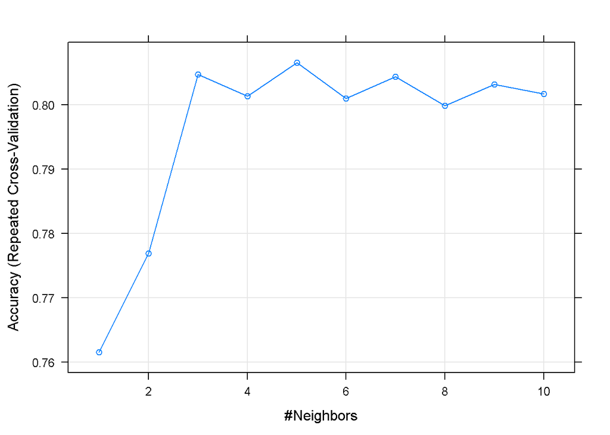

```r
set.seed(1)
# Cross-Validated (10 fold, repeated 3 times)
ctrl <- trainControl(method="repeatedcv",repeats = 3)
# preprocess scale is very important in KNN
knnFit <- train(Survived ~ ., data = cTrain, method = "knn", trControl = ctrl, preProcess = c("scale"), tuneGrid = expand.grid(k=seq(from=1, to=10, by=1)))
plot(knnFit)
```

```r
knnFit
```

```
## k-Nearest Neighbors
##
## 889 samples
##   7 predictor
##   2 classes: '0', '1'
##
## Pre-processing: scaled (9)
## Resampling: Cross-Validated (10 fold, repeated 3 times)
## Summary of sample sizes: 801, 800, 800, 800, 800, 800, ...
## Resampling results across tuning parameters:
##
##   k   Accuracy   Kappa
##    1  0.7615509  0.4968246
##    2  0.7769237  0.5280337
##    3  0.8046689  0.5803101
##    4  0.8013023  0.5726055
##    5  0.8065373  0.5832884
##    6  0.8009321  0.5701277
##    7  0.8042986  0.5761985
##    8  0.7998085  0.5655787
##    9  0.8031580  0.5694352
##   10  0.8016641  0.5671918
##
## Accuracy was used to select the optimal model using  the largest value.
## The final value used for the model was k = 5.
```

It seems that k=5 gives the best accuracy. Predict test data with 5-KNN

```r
# remove new factor in Title
cTest$Title[cTest$Title=='Dona'] = 'Miss'
# update levels
cTest$Title = factor(cTest$Title)
pr <- predict(knnFit,newdata = cTest)
write.csv(data.frame(PassengerId = test$PassengerId, Survived = pr), file = "TitanicKNN.csv")
```

## Conclusion

There is an opinion that for data with small number of observation we should minimize variance and thus select models with many constrains, such as lm, glm, lda. For data with many observations, we can guess that sample distribution is close to real one and thus we just need to fit it well (and minimize bias instead of variance), so tree models, QDA, KNN and others that tend to overfit gives better results.